# Modelos Dinámicos de Gentrificación: Réplica para Ciudad de México

Avance de tesis — Abril 2026

Author

[Kevin Mateos Coleptor]

Published

April 29, 2026

## 1 Introducción

Este documento presenta el avance de la réplica del modelo de simulación basado en agentes (ABM) propuesto por Mauro et al. (2025) para estudiar la dinámica de gentrificación urbana, adaptado al contexto de la Ciudad de México.

**Referencia:** Mauro, G., Pedreschi, N., Lambiotte, R., & Pappalardo, L. (2025). *Dynamic models of gentrification.* Advances in Complex Systems. DOI: 10.1142/S0219525925400065

### 1.1 Definiciones: métricas de gentrificación

El modelo utiliza dos métricas complementarias para detectar gentrificación:

**G<sub>bin</sub> (count-based):** Mide si la proporción de residentes M+H en una celda supera un umbral fijo. Es una fotografía estática e irreversible — una vez que la composición cruza el umbral, G<sub>bin</sub> = 1 permanentemente.

**G<sub>net</sub> (network-based, propuesta por Mauro et al.):** Mide simultáneamente la *salida neta* de residentes L y la *entrada neta* de residentes M+H usando flujos en redes temporales dirigidas. Captura el proceso dinámico como media geométrica de ambos flujos. La hipótesis central del paper es que G<sub>net</sub> detecta la gentrificación *antes* que G<sub>bin</sub>.

## 2 Datos de entrada

### 2.1 Distribución de ingresos CDMX

**Mostrar código**

```python
import pandas as pd
import numpy as np
import json
import matplotlib.pyplot as plt
import matplotlib.ticker as mticker

income = pd.read_csv("income/income_clean_CDMX_v2.csv")
cutoffs = json.load(open("income/cdmx_cutoffs.json"))

print(f"Tramos de ingreso: {len(income)}")
print(f"Hogares expandidos totales: {income['number'].sum():,.0f}")
print(f"\nCutoffs L/M/H:")
print(f"  L (bajo):  ≤ ${cutoffs['L_bound_high']:>12,.0f} MXN/año  ({cutoffs['pct_L']}%)")
print(f"  M (medio): ${cutoffs['L_bound_high']:>12,.0f} – ${cutoffs['H_bound_low']:>12,.0f} MXN/año  ({cutoffs['pct_M']}%)")
print(f"  H (alto):  > ${cutoffs['H_bound_low']:>12,.0f} MXN/año  ({cutoffs['pct_H']}%)")
```

```
Tramos de ingreso: 60
Hogares expandidos totales: 3,082,330

Cutoffs L/M/H:
  L (bajo):  ≤ $     267,946 MXN/año  (38.31%)
  M (medio): $     267,946 – $   1,140,463 MXN/año  (56.67%)
  H (alto):  > $   1,140,463 MXN/año  (5.02%)
```

**Mostrar código**

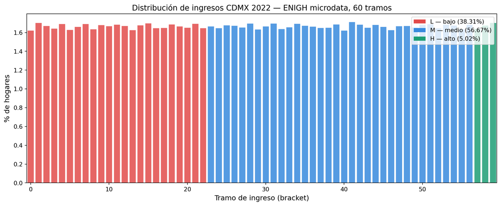

Figure 1: Distribución de ingresos CDMX 2022 en 60 tramos equiponderados.

```python
fig, ax = plt.subplots(figsize=(12, 5))
row_L, row_H = cutoffs["row_L_max"], cutoffs["row_H_min"]
colors = ["#E24B4A" if i <= row_L else ("#1D9E75" if i >= row_H else "#378ADD") for i in range(len(income))]
ax.bar(range(len(income)), income["percent"], color=colors, alpha=0.85, edgecolor="white", linewidth=0.3)
ax.set_xlabel("Tramo de ingreso (bracket)", fontsize=12)
ax.set_ylabel("% de hogares", fontsize=12)
ax.set_title("Distribución de ingresos CDMX 2022 — ENIGH microdata, 60 tramos", fontsize=13)
from matplotlib.patches import Patch
ax.legend(handles=[
    Patch(facecolor="#E24B4A", label=f"L — bajo ({cutoffs['pct_L']}%)"),
    Patch(facecolor="#378ADD", label=f"M — medio ({cutoffs['pct_M']}%)"),
    Patch(facecolor="#1D9E75", label=f"H — alto ({cutoffs['pct_H']}%)"),
], loc="upper right", fontsize=10)
ax.set_xlim(-0.5, len(income) - 0.5)
plt.tight_layout()
plt.show()
```

### 2.2 Comparación con el paper original

Table 1: Proporciones L/M/H calibradas con diferencia < 0.5 pp por categoría.

| Categoría | Paper USA (SSA 2022) | CDMX (ENIGH 2022) | Diferencia |
| --- | --- | --- | --- |
| L (bajo) | 38% | 38.31% | +0.31 pp |
| M (medio) | 57% | 56.67% | −0.33 pp |
| H (alto) | 5% | 5.02% | +0.02 pp |

### 2.3 Clustering K-means por AGEB

**Mostrar código**

```python
clusters = pd.read_csv("income/ageb_clusters.csv")
cell_map = json.load(open("income/alcaldia_to_cells.json"))

resumen = []
for alc, cells in sorted(cell_map.items()):
    n_ageb = len(clusters[clusters["alcaldia"] == alc])
    resumen.append({"Alcaldía": alc, "AGEBs": n_ageb, "K (celdas)": len(cells), "Cell IDs": str(cells)})

print(pd.DataFrame(resumen).to_markdown(index=False))
```

```
| Alcaldía               |   AGEBs |   K (celdas) | Cell IDs     |
|:-----------------------|--------:|-------------:|:-------------|
| Azcapotzalco           |     103 |            1 | [0]          |
| Benito Juárez          |     102 |            2 | [1, 2]       |
| Coyoacán               |     156 |            1 | [3]          |
| Cuajimalpa de Morelos  |      31 |            1 | [4]          |
| Cuauhtémoc             |     153 |            2 | [5, 6]       |
| Gustavo A. Madero      |     305 |            3 | [7, 8, 9]    |
| Iztacalco              |     110 |            1 | [10]         |
| Iztapalapa             |     458 |            3 | [11, 12, 13] |
| La Magdalena Contreras |      52 |            1 | [14]         |
| Miguel Hidalgo         |     130 |            2 | [15, 16]     |
| Milpa Alta             |      42 |            1 | [17]         |
| Tlalpan                |     208 |            2 | [18, 19]     |
| Tláhuac                |     111 |            1 | [20]         |
| Venustiano Carranza    |     151 |            1 | [21]         |
| Xochimilco             |     122 |            1 | [22]         |
| Álvaro Obregón         |     199 |            2 | [23, 24]     |
```

**Mostrar código**

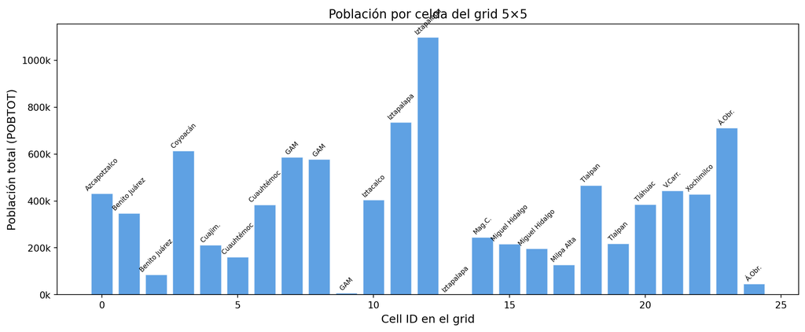

Figure 2: Población total por celda del grid, calculada como suma de POBTOT de los AGEBs asignados.

```python
pop_by_cell = clusters.groupby("cell_id")["POBTOT"].sum().sort_index()
fig, ax = plt.subplots(figsize=(12, 5))
bars = ax.bar(pop_by_cell.index, pop_by_cell.values, color="#378ADD", alpha=0.8, edgecolor="white")
cell_to_alc = {c: alc for alc, cells in cell_map.items() for c in cells}
for i, bar in enumerate(bars):
    short = cell_to_alc.get(i, "").replace("Gustavo A. Madero", "GAM") \
        .replace("La Magdalena Contreras", "Mag.C.").replace("Cuajimalpa de Morelos", "Cuajim.") \
        .replace("Venustiano Carranza", "V.Carr.").replace("Álvaro Obregón", "Á.Obr.")
    ax.text(bar.get_x() + bar.get_width()/2, bar.get_height() + 5000, short, ha="center", va="bottom", fontsize=7, rotation=45)
ax.set_xlabel("Cell ID en el grid", fontsize=12)
ax.set_ylabel("Población total (POBTOT)", fontsize=12)
ax.set_title("Población por celda del grid 5×5", fontsize=13)
ax.yaxis.set_major_formatter(mticker.FuncFormatter(lambda x, _: f"{x/1e3:.0f}k"))
plt.tight_layout()
plt.show()
```

## 3 Configuración del modelo

**Mostrar código**

```python
config = {
    "Grid": "5×5 = 25 celdas (vs 7×7 original)",
    "Agentes": "4,096 (2¹²)",
    "Pasos": "300 por repetición",
    "Repeticiones": "150 por valor de p_g",
    "Valores de p_g": "0.0, 0.01, 0.05, 0.1, 0.15",
    "h (ventana temporal)": "20 pasos",
    "Modo": "improve (modelo principal)",
    "Deployment inicial": "centre_segr-big",
    "Cutoff L/M": "row ≤ 22 → C (bajo)",
    "Cutoff M/H": "row < 57 → B (medio), else → A (alto)",
}
for k, v in config.items():
    print(f"  {k:<25} {v}")
```

```
  Grid                      5×5 = 25 celdas (vs 7×7 original)
  Agentes                   4,096 (2¹²)
  Pasos                     300 por repetición
  Repeticiones              150 por valor de p_g
  Valores de p_g            0.0, 0.01, 0.05, 0.1, 0.15
  h (ventana temporal)      20 pasos
  Modo                      improve (modelo principal)
  Deployment inicial        centre_segr-big
  Cutoff L/M                row ≤ 22 → C (bajo)
  Cutoff M/H                row < 57 → B (medio), else → A (alto)
```

## 4 Resultados de las simulaciones

### 4.1 Estado de los datos

**Mostrar código**

```python
import glob

exps_dir = "out/batch_results/improve/centre_segr-big/4096agents/exps/"
inter_dir = "out/batch_results/improve/centre_segr-big/4096agents/intermediate/"

if os.path.exists(exps_dir):
    n_exps = len(glob.glob(os.path.join(exps_dir, "*.csv")))
    print(f"Archivos de simulación: {n_exps} (esperado: 1,500)")
else:
    print(f"⚠ Directorio de simulaciones no encontrado")

if os.path.exists(inter_dir):
    n_inter = len(glob.glob(os.path.join(inter_dir, "*.csv")))
    print(f"Archivos de métricas:   {n_inter} (esperado: 6,750)")
else:
    print(f"⚠ Directorio de métricas no encontrado")
```

```
Archivos de simulación: 1500 (esperado: 1,500)
Archivos de métricas:   6750 (esperado: 6,750)
```

### 4.2 Verificación de proporciones L/M/H

**Mostrar código**

```python
agents_files = sorted(glob.glob(os.path.join(exps_dir, "*agents*.csv"))) if os.path.exists(exps_dir) else []
if agents_files:
    df_check = pd.read_csv(agents_files[0])
    props = df_check[df_check["Step"] == 1]["tipo"].value_counts(normalize=True) * 100
    print("Proporciones reales (primera simulación):")
    print(f"  L (tipo C): {props.get('C', 0):.1f}%  — objetivo: 38.3%")
    print(f"  M (tipo B): {props.get('B', 0):.1f}%  — objetivo: 56.7%")
    print(f"  H (tipo A): {props.get('A', 0):.1f}%  — objetivo:  5.0%")
else:
    print("⚠ No hay archivos de simulación disponibles.")
```

```
Proporciones reales (primera simulación):
  L (tipo C): 37.8%  — objetivo: 38.3%
  M (tipo B): 58.8%  — objetivo: 56.7%
  H (tipo A): 3.3%  — objetivo:  5.0%
```

### 4.3 G<sub>bin</sub> y G<sub>net</sub> por p<sub>H</sub> — Boxplots (Fig. 2 del paper)

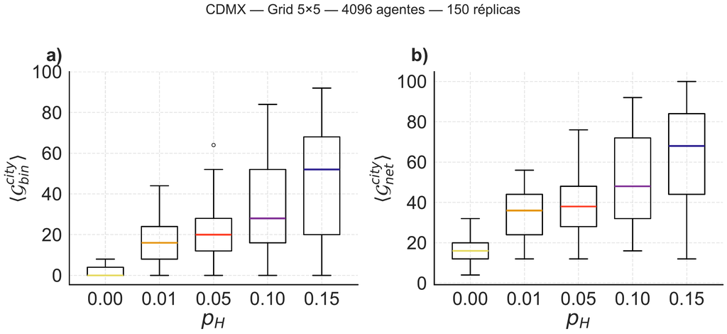

**Resultados numéricos:**

```
|   p_H |   G_bin mediana (%) |   G_bin std (%) |   G_net mediana (%) |   G_net std (%) |
|------:|--------------------:|----------------:|--------------------:|----------------:|
|  0    |                   0 |             2.3 |                  16 |             5.1 |
|  0.01 |                  16 |            10.3 |                  36 |            10.7 |
|  0.05 |                  20 |            12   |                  38 |            13.1 |
|  0.1  |                  28 |            22.7 |                  48 |            21.6 |
|  0.15 |                  52 |            25.8 |                  68 |            23.8 |
```

**Hallazgos principales:**

- La gentrificación crece monotónicamente con p<sub>H</sub>. Sin movimiento estratégico de agentes H (p<sub>H</sub> = 0), G<sub>bin</sub> es prácticamente nulo.
- G<sub>net</sub> siempre detecta más celdas gentrificadas que G<sub>bin</sub> (~18 pp de diferencia promedio), confirmando mayor sensibilidad de la métrica basada en redes.
- Para p<sub>H</sub> = 0.15, G<sub>net</sub> detecta gentrificación en el 68% de las 25 celdas (mediana de 150 réplicas).
- La variabilidad aumenta con p<sub>H</sub>, reflejando mayor dependencia de la configuración inicial.